# PA1_Reproducible Research

Daniel Arboleda

19/7/2020

# **Project Asssignment 1 - Activity Monitoring Data Analysis**

## *Introduction*

This is a data analysis exercise to show patterns in the personal activity behavior of one anonymous individual. the data consists of two months of data from this individual collected during the months of October and November, 2012 and include the number of steps taken in 5 minute intervals each day.

The variables included in this dataset are:

- steps: Number of steps taking in a 5-minute interval (missing values are coded as NA)
- date: The date on which the measurement was taken in YYYY-MM-DD format
- interval: Identifier for the 5-minute interval in which measurement was taken

This analysis is divided into five sections, this first one that describes the process of loading and preprocessing the data, the second one that calculates the global mean and median steps, the third one that calculates the same but splits the analysis by day, the fourth section shows the same calculations introducing imputations on missing values to reduce bias, and finally the fifth section shows differences in activity between weekdays and weekends.

## Section 1 - Loading and preprocessing the data

We get the data from the course website, unzip it and load it into R. We do this with the following code.

```r
FURL <- "https://d396qusza40orc.cloudfront.net/repdata%2Fdata%2Factivity.zip"
download.file(FURL, destfile = "./repdata_data_activity.zip", method = "curl")
unzip("repdata_data_activity.zip")
data <- read.csv("activity.csv", colClasses="character")
data$steps <- as.integer(data$steps)
data$interval <- as.integer(data$interval)
data$date <- as.Date(data$date, format = "%Y-%m-%d")
str(data)
```

```
## 'data.frame':    17568 obs. of  3 variables:
##  $ steps   : int  NA NA NA NA NA NA NA NA NA NA ...
##  $ date    : Date, format: "2012-10-01" "2012-10-01" ...
##  $ interval: int  0 5 10 15 20 25 30 35 40 45 ...
```

Now the data is loaded and ready to be used.

## *Section 2 - What is mean total number of steps taken per day?*

Let’s take a look on the histogram of the steps by day to answer this question

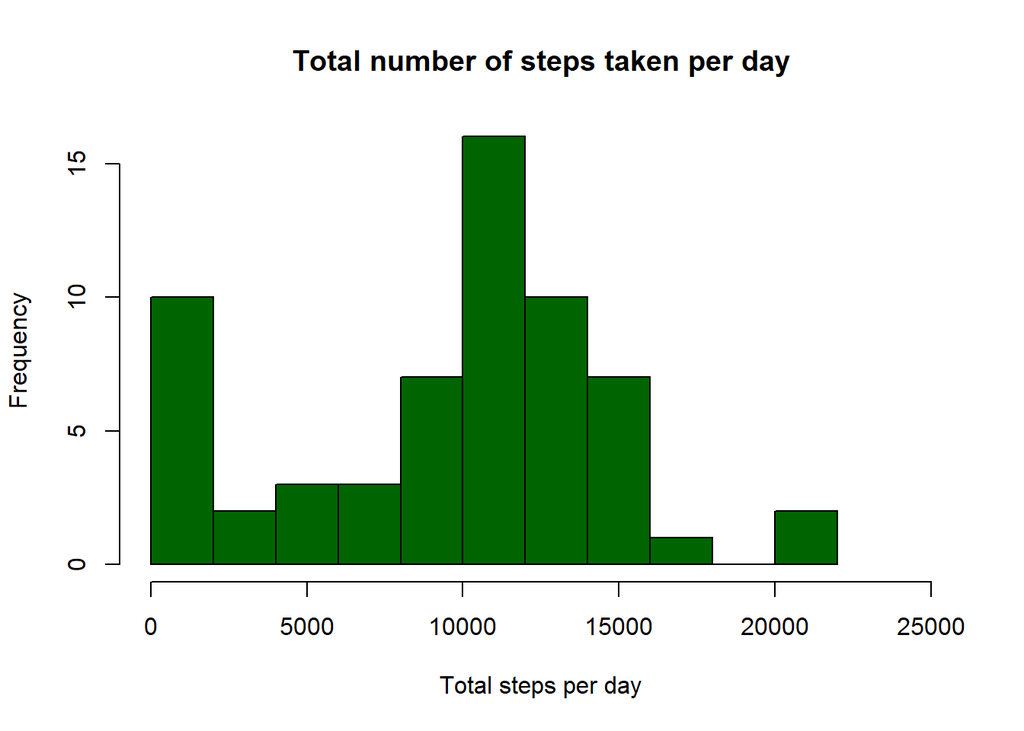

```r
steps_day <- with(data, aggregate(steps, by = list(date), FUN = sum, na.rm = TRUE))
names(steps_day) <- c("date", "steps")
hist(steps_day$steps, main = "Total number of steps taken per day",
     xlab = "Total steps per day", col = "dark green", breaks = 8, xlim = c(0, 25000))
```

And so, we can take a look at the mean and median steps per day.

```r
mean(steps_day$steps)
```

```
## [1] 9354.23
```

```r
median(steps_day$steps)
```

```
## [1] 10395
```

## *Section 3 - What is the average daily activity pattern?*

The following plot shows average activity within days considering a 5 - minute interval in which the steps were measured.

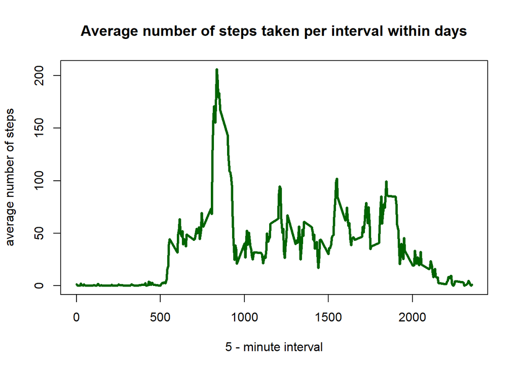

```r
steps_interval <- with(data, aggregate(steps, by = list(interval), FUN = mean, na.rm = TRUE))
names(steps_interval) <- c("interval", "mean_steps")
plot(steps_interval$interval, steps_interval$mean_steps, type = "l",
     lwd = 3, main = "Average number of steps taken per interval within days",
     xlab = "5 - minute interval", ylab = "average number of steps",
     col = "dark green")
```

To know which 5-minute interval, on average across all the days in the dataset, contains the maximum number of steps, we obtain it with the following code.

```r
steps_interval[which.max(steps_interval$mean_steps), ]
```

```
##     interval mean_steps
## 104      835   206.1698
```

## *Section 4 - Imputing missing values*

Let’s start by identifying which observations have missing values

```r
sum(is.na(data))
```

```
## [1] 2304
```

Since there are lots of missing values per day, it is possible that this generates a bias in the analysis. So, it is feasible to impute missing values taking into reference the average steps by 5-minute interval. And so we create a new dataset.

```r
imp_steps <- steps_interval$mean_steps[match(data$interval, steps_interval$interval)]
data_imp <- transform(data, steps = ifelse(is.na(data$steps), yes = imp_steps,
                                           no = data$steps))
```

And now we compare the values and histogram with the new dataset against the original to see if there are any differences.

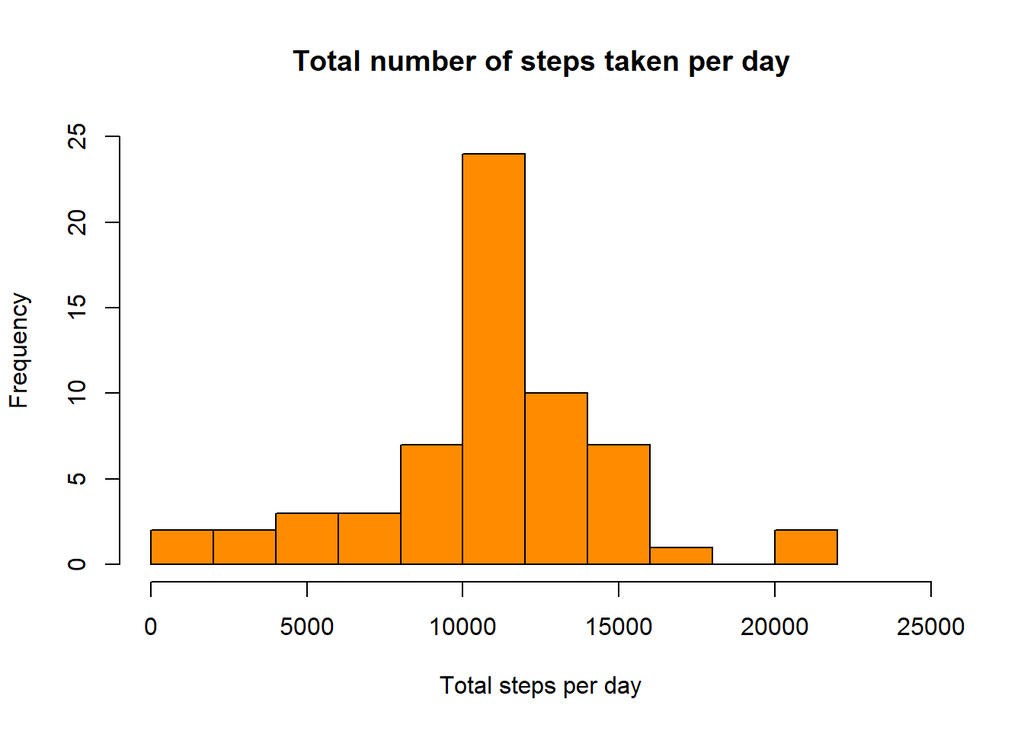

```r
steps_day_imp <- aggregate(steps ~ date, data_imp, sum)
names(steps_day_imp) <- c("date", "steps")
hist(steps_day_imp$steps, main = "Total number of steps taken per day",
     xlab = "Total steps per day", col = "dark orange", breaks = 8,
     xlim = c(0, 25000), ylim = c(0, 25))
```

```r
mean(steps_day_imp$steps)
```

```
## [1] 10766.19
```

```r
median(steps_day_imp$steps)
```

```
## [1] 10766.19
```

The comparison shows that original data is biased by missing values, so it shows more values to the left of the distribution and has a lower mean and median. On the other hand, the dataset with the imputed step values, shows a centered distribution having an identical mean and median.

## *Section 5 - Are there differences in activity patterns between weekdays and weekends?*

For this analysis I’m using the imputed dataset. The first thing is to create a factor variable classifying weekdays and weekends.

```r
day_type <- sapply(data_imp$date, function(i) {
  wd <- weekdays(i)
  ifelse (wd == "sábado" | wd == "domingo", "weekend", "weekday")
})
data_imp$day_type <- as.factor(day_type)
```

With the new variable created, it is possible to compare the activity between weekdays and weekends, so this is shown in the following plot.

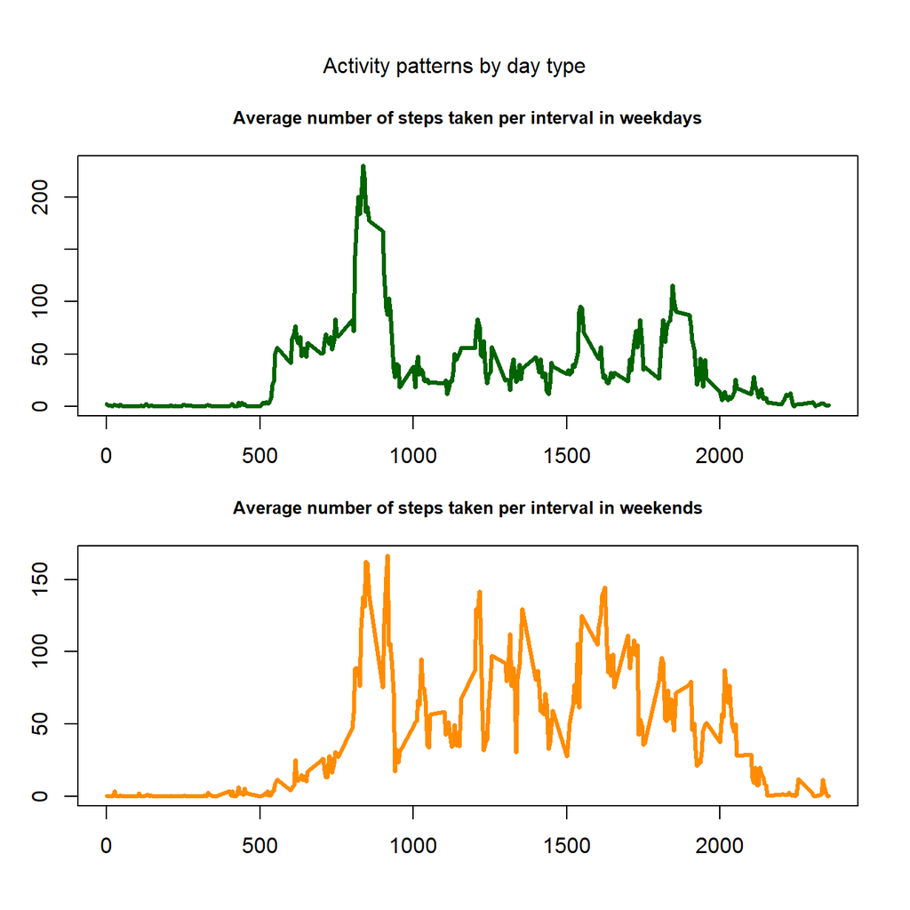

```r
act_date <- aggregate(steps ~ interval + day_type, data_imp, mean, na.rm = TRUE)
wkndb <- act_date[act_date$day_type == "weekend", ]
wkddb <- act_date[act_date$day_type == "weekday", ]
par(mfrow = c(2,1), mar = c(2, 2, 3, 1), oma = c(2, 1, 3, 1))
plot(wkddb$interval, wkddb$steps, type = "l",
     lwd = 3, main = "Average number of steps taken per interval in weekdays",
     xlab = "5 - minute interval", ylab = "average number of steps",
     col = "dark green", cex.main = 0.8)
plot(wkndb$interval, wkndb$steps, type = "l",
     lwd = 3, main = "Average number of steps taken per interval in weekends",
     xlab = "5 - minute interval", ylab = "average number of steps",
     col = "dark orange", cex.main = 0.8)
mtext("Activity patterns by day type", outer = TRUE)
```

We conclude the analysis with this graphic.